# Hierarchical Models, Random Samples, Statistics, Sampling Distributions, and the Central Limit Theorem

## 3.2 Gamma Distribution

Considering the Gamma distribution $\text{Gamma}(\alpha = 2, \beta = 1.5)$. We will get random samples from this distribution and check out the histograms for each of these samples. We expect that as the sample size increases, the sample distribution will provide an increasingly improved approximation of the the true distribution.

### 3.2.1 Density of $\text{Gamma}(\alpha = 2, \beta = 1.5)$.

Plotting the density curve of $\text{Gamma}(\alpha = 2, \beta = 1.5)$,

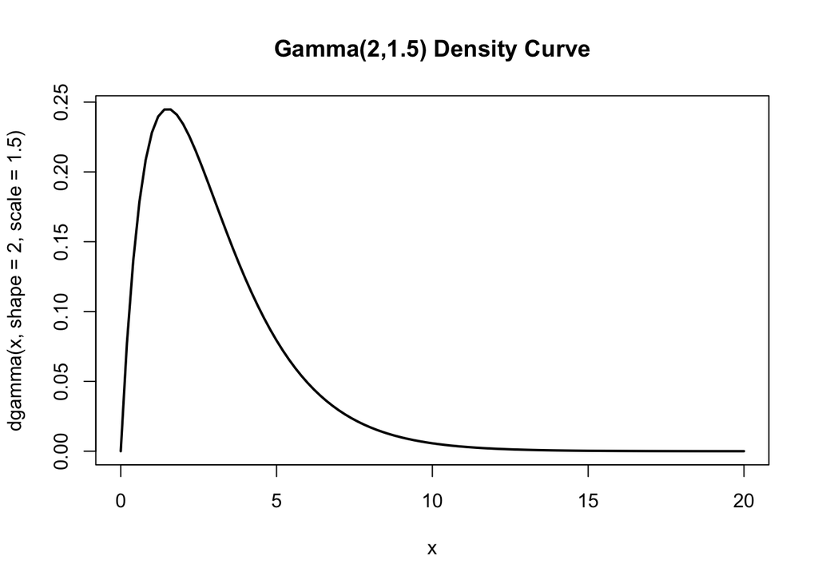

```r
x <- 1:10000
curve(dgamma(x, shape=2, scale=1.5), from=0, to=20, lwd=2, main="Gamma(2,1.5) Density Curve")
```

### 3.2.2 Sample distributions

For the sample sizes $4, 7, 10, 15, 20, 30, 40, 80, 1000$ getting random samples of respective size, and plotting the histograms for each of these samples.

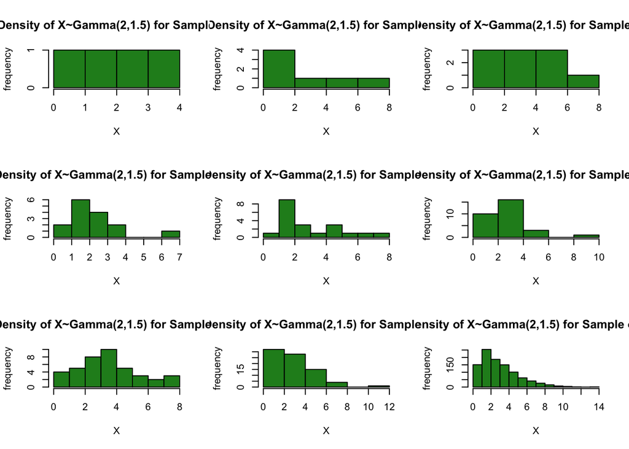

```r
par(mfrow=c(3,3))
for (n in c(4,7,10,15,20,30,40,80,1000)) {
    hist(rgamma(n, shape=2, scale=1.5), main=paste0("Prob Density of X~Gamma(2,1.5) for Sample of Size ", n), xlab="X", ylab="frequency", col = 'forestgreen')
}
```

```r
# As sample size increases, empirical histogram approaches that of gamma distribution
```

# 4 Sampling Distributions

Given an ordered random sample of size 15. Writing functions ‘order_1, order_3, order_15’ that take input a sample ‘samp’ and calculate the 1st smallest, 3rd smallest, and 15th smallest entry in ‘samp’. Instead of ordering a random sample in each of these functions, all usages of these functions order the relevant samples before passing it.

```r
order_1 <- function(samp) {
    return(samp[1,])
}

order_3 <- function(samp) {
    return(samp[3,])
}

order_15 <- function(samp) {
    return(samp[15,])
}

# For question at the end
order_13 <- function(samp) {
    return(samp[13,])
}

order_14 <- function(samp) {
    return(samp[14,])
}
```

## 4.1 Order Statistics

Suppose we have a sample of size 15 coming from the uniform discrete distribution on the set $\{1, 2, 3, 4, 5\}$. Use the functions ‘order_1, order_3, order_15’ and the replicate command to calculate the empirical sampling distribution of the given order statistics.

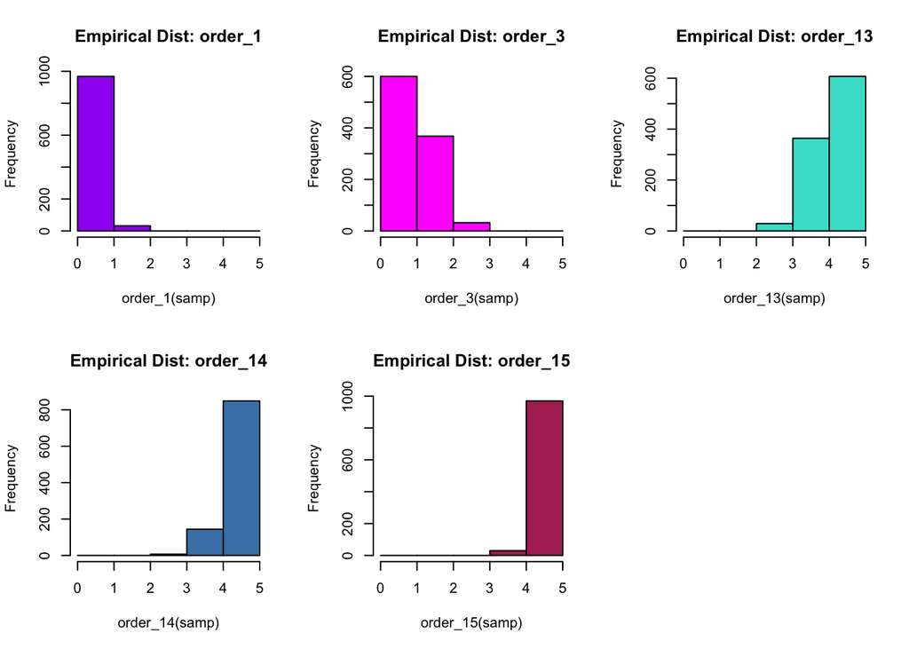

```r
samp_sorted <- function() {
   s <- replicate(1000, sample(c(1,2,3,4,5), size=15, replace=TRUE))
    for (i in 1:1000) {
     s[,i] <- sort(s[,i])
    }
   return(s)
}

samp <- samp_sorted()

par(mfrow=c(2,3))
hist(order_1(samp), breaks=c(0,1,2,3,4,5), col=colors[4], main="Empirical Dist: order_1")
hist(order_3(samp), breaks=c(0,1,2,3,4,5), col=colors[8], main="Empirical Dist: order_3")
hist(order_13(samp), breaks=c(0,1,2,3,4,5), col=colors[7], main="Empirical Dist: order_13")
hist(order_14(samp), breaks=c(0,1,2,3,4,5), col=colors[5], main="Empirical Dist: order_14")
hist(order_15(samp), breaks=c(0,1,2,3,4,5), col=colors[6], main="Empirical Dist: order_15")
```

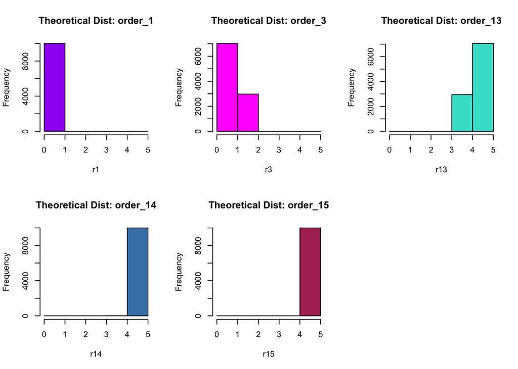

```r
# We know that the order statistic is a beta distributed random variable. Let us plot the theoretical distributions
r1 <- replicate(10000, 5*{mean(rbeta(15, 1, 15))})
r3 <- replicate(10000, 5*{mean(rbeta(15, 3, 13))})
r15 <- replicate(10000, 5*{mean(rbeta(15, 15, 1))})
r13 <- replicate(10000, 5*{mean(rbeta(15, 13, 3))})
r14 <- replicate(10000, 5*{mean(rbeta(15, 14, 2))})

par(mfrow=c(2,3))
hist(r1, breaks=c(0,1,2,3,4,5), col=colors[4], main="Theoretical Dist: order_1")
hist(r3, breaks=c(0,1,2,3,4,5), col=colors[8], main="Theoretical Dist: order_3")
hist(r13, breaks=c(0,1,2,3,4,5), col=colors[7], main="Theoretical Dist: order_13")
hist(r14, breaks=c(0,1,2,3,4,5), col=colors[5], main="Theoretical Dist: order_14")
hist(r15, breaks=c(0,1,2,3,4,5), col=colors[6], main="Theoretical Dist: order_15")
```

```r
# Empirical distributions of order_13, order_14, and order_15 are reflections about the line x=5/2 of order_3, order_2, and order_1 respectively.
```

## 4.2 Central Limit Theorem

### 4.2.1 Exponential Distribution

Using the replicate function to get the histograms for the sampling distribution of the sample mean when working with sample sizes $n = 1, 2, 3, 4, 15, 500$.

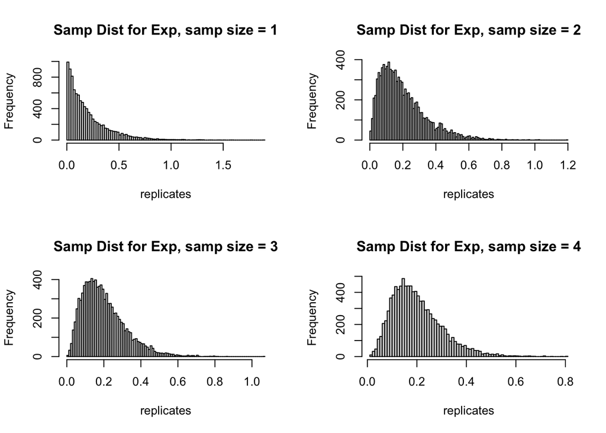

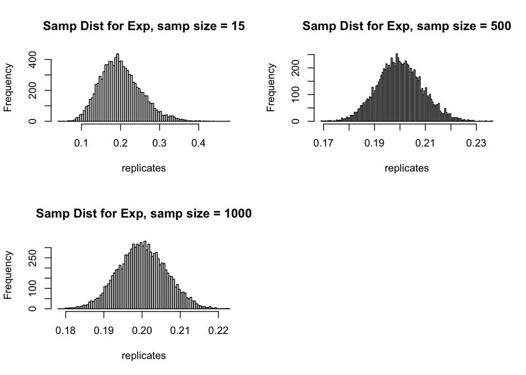

```r
samp_sizes  <- c(1, 2, 3, 4, 15, 500, 1000)

par(mfrow=c(2,2))
for(size in samp_sizes){
  replicates <- replicate(10000, {
    mean(rexp(size, rate = 5))
  })
  hist(replicates, breaks = 100,
       main = paste("Samp Dist for Exp, samp size =", size ))
}
```

```r
# Distribution approaches normal as sample size increases.
```

### 4.2.2 Discrete Uniform distibution

Suppose we are working with the discrete uniform random variable taking values $\{1, 2, 3, 4, 5, 6\}$.

```r
# Takes input "n" and returns a random sample of size "n" from discrete uniform distribution
disc_samp <- function(n) {
    s <- sample(c(1,2,3,4,5,6), size=n, replace=TRUE)
    r <- replicate(10000, s)
    return(r)
}
```

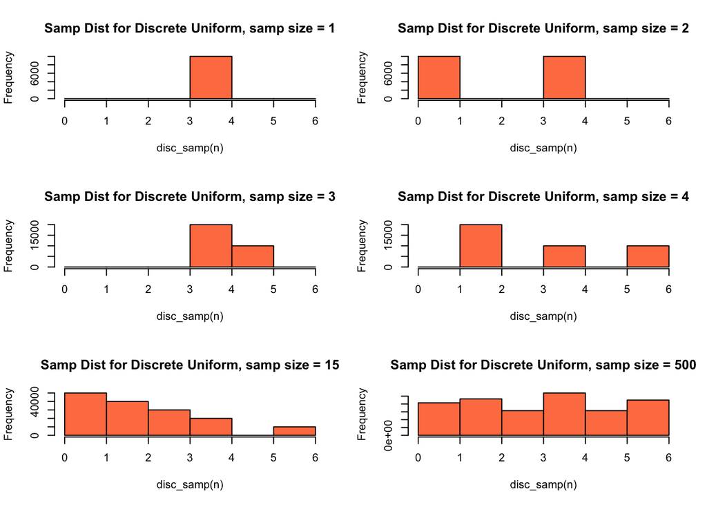

```r
samp_sizes <- c(1, 2, 3, 4, 15, 500)
par(mfrow=c(3,2))
for(n in samp_sizes){
    hist(disc_samp(n), breaks=c(0,1,2,3,4,5,6), col="coral",
        main = paste("Samp Dist for Discrete Uniform, samp size =", n))
}
```

```r
# Distribution approaches uniformity as sample size increases.
```

## 4.3 Continuous Uniform distibution

Suppose we are working with the Continuous uniform random variable taking values on $(0,1)$.

```r
# Takes input "n" and returns a random sample of size "n" from continuous uniform distribution.
cont_uni_samp <- function(n) {
    r <- replicate(10000, mean(runif(n,0,1)))
    return(r)
}
```

Using the “cont_uni_samp” function and the replicate function to to get the histograms for the sampling distribution of the sample mean when working with sample sizes $n = 1, 2, 3, 4, 15, 500$.

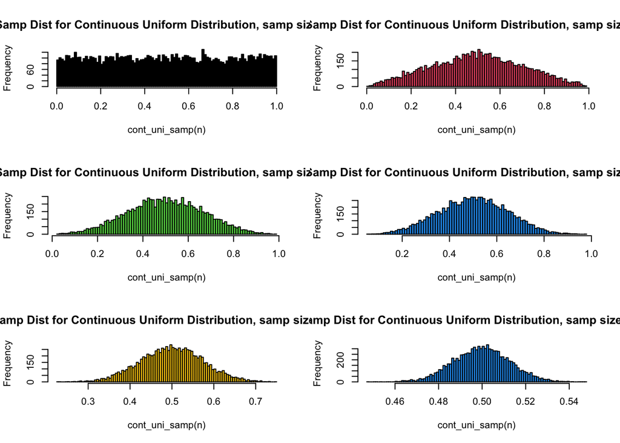

```r
par(mfrow=c(3,2))
for(n in samp_sizes) {
    hist(cont_uni_samp(n), breaks=100, main = paste("Samp Dist for Continuous Uniform Distribution, samp size =", n), col=n)
}
```

```r
# Distribution approaches normal as sample size increases. Key concept and interesting distinction from discrete uniform.
```